# Concord: Cross-file contradiction detection and leak guarding for code and documentation

10 June 2026

# Summary

Large repositories mix prose and code: pricing pages, onboarding guides and security policies alongside the configuration files, string literals and constants that drive the product. As these evolve independently, hard facts drift apart. A price is quoted one way on a pricing page and another in an FAQ; an anonymity floor reads `MIN_RESPONDENTS = 8` in a Python module but `"min_n": 5` in a config file. Such contradictions are easy to ship and hard to find by hand.

`Concord` (installed as `concord-ai`) is an open-source Python tool that keeps a repository telling one story. It offers three composable capabilities: (1) a **typed-value contradiction radar** that surfaces semantically similar passages carrying disjoint hard values of the same kind (prices, thresholds, durations, and named code or config constants) across both prose and source; (2) a **deterministic leak guard** that fails continuous integration if a banned term (an internal codename, a retired product name) reaches a file marked public; and (3) **semantic retrieval** that answers a plain-language question with the relevant passages, each cited to `file:line`.

To work across file types, Concord extracts the meaningful units from each through a modular per-extension registry (visible text from HTML, skipping `<script>` and `<style>`; comments, string literals and named constants from code and configuration; paragraphs from documentation), so supporting a new language is a single function. The index is built incrementally: `concord update` re-embeds only the files a `git diff` reports as changed (with a content-hash fallback when there is no git), and `concord init` scaffolds the index and a private ruleset and adds both to `.gitignore`, so neither is ever committed. Everything runs on-device using local sentence embeddings via `sentiment.ai` (Wiseman 2026); an optional language-model pass can adjudicate flagged contradictions, but the core pipeline is deterministic and free to run.

# Statement of need

**Contradictions hide across files, and across file types.** A `grep` for `$49` will not find a conflicting `$39` elsewhere, and no reviewer remembers every place a value is stated, still less that a threshold in a Python module disagrees with a JSON config. Concord’s radar pairs passages by embedding similarity and shared subject words, then flags those carrying same-type but disjoint typed values (prices, thresholds, durations, percentages, and numeric config constants). It detects same-type values in similar contexts rather than verifying that two occurrences name the identical constant, so it is a candidate generator, not a verdict. On a small synthetic corpus (five documents, twelve labelled conflict pairs), at the production similarity threshold (0.88) it recovers 8 of 12 conflicts (recall 0.67) at precision 0.50; relaxing the threshold to 0.60, appropriate for so small a corpus, recovers all twelve at precision 0.17. The design favours recall: a missed inconsistency is expensive, a false candidate costs one dismissal, and an optional language-model pass adjudicates the candidates by reading full context.

**Auditing a repository with a language model is token-expensive.** Feeding a whole repository into context to answer one question scales poorly; Concord instead retrieves a fixed number of citable passages, ordered by embedding similarity. By construction this bounds the read cost: reading the top ten passages costs a few hundred tokens regardless of corpus size (150 to 307 tokens across four repositories from 17K to 2.08M corpus tokens, Figure 1), while reading the whole corpus would grow with it. The figure characterises the read budget, not retrieval quality; quality is measured separately on the labelled corpus above. Neighbouring tools solve different problems: prose linters such as `Vale` (Kato 2024) enforce per-sentence rules but do not reason across files about whether two passages agree; retrieval frameworks such as `LlamaIndex` (Liu 2022) provide general document search but are not oriented toward consistency auditing, `file:line` citation, or deterministic leak prevention in CI; and knowledge-graph tools such as Graphify (safishamsi 2026) map how concepts relate, returning concept nodes and file pointers rather than the conflicting text. The two surface different things: on one query over a large private repository (*“find contradictory pricing information”*), Graphify returned a concept map of 46 nodes and file pointers, while Concord returns the verbatim passages cited to `file:line`.

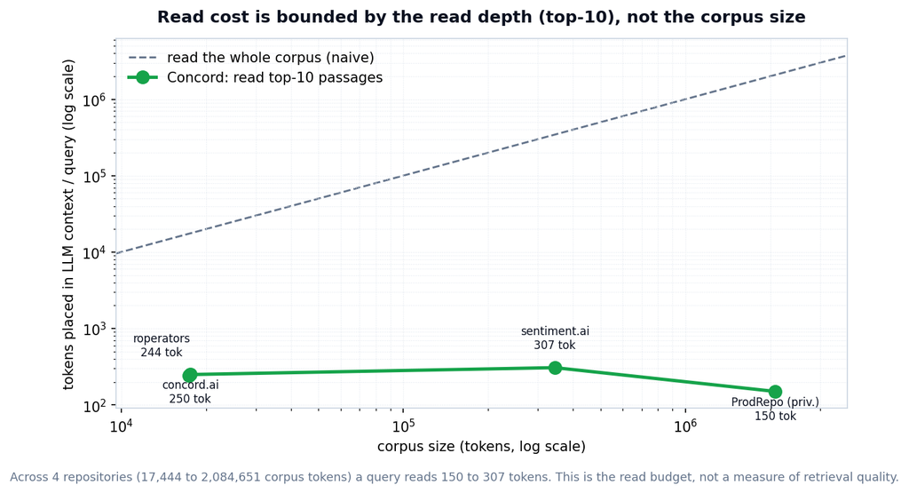

Concord is aimed at technical writers and developers maintaining product, policy and configuration that must stay consistent, and at LLM-agent workflows that need grounded, citable context from a repository without ingesting it whole.

# Functionality and design

Files become citable, line-numbered passages in two ways. For the semantic index, structure-aware extraction keeps the contradiction-worthy content and discards syntax; for the leak guard, the raw text is scanned, because a codename can hide in an attribute or a minified string that extraction would strip. Passages are embedded into a NumPy matrix under a gitignored `.concord/` directory; search is exact cosine nearest-neighbour, with multiple query phrasings max-merged and a maximal-marginal-relevance re-ranker (Carbonell and Goldstein 1998) suppressing near-duplicates. The contradiction detector compares only value-bearing passages, so its cost is quadratic in that subset, not the whole corpus.

The leak guard is separate and dependency-light: no machine-learning packages, exact string matching over a user-supplied term list, run on every commit. Protected terms live in a gitignored ruleset, so the sensitive list never enters version control; only a generic example ships with the package. `concord types` reports exactly which file types are indexed. The software includes a test suite, continuous integration, documentation, a reproducible benchmark with a public synthetic corpus, and an MIT licence.

# Acknowledgements

Concord is developed by Linnet Labs. Its semantic features build on the `sentiment.ai` embedding package.

# References

Carbonell, Jaime, and Jade Goldstein. 1998. “The Use of MMR, Diversity-Based Reranking for Reordering Documents and Producing Summaries.” *Proceedings of the 21st Annual International ACM SIGIR Conference on Research and Development in Information Retrieval*, 335–36. https://doi.org/10.1145/290941.291025.

Kato, Joseph. 2024. *Vale: A Syntax-Aware Linter for Prose*. [Https://vale.sh](https://vale.sh).

Liu, Jerry. 2022. *LlamaIndex: A Data Framework for LLM Applications*. [Https://github.com/run-llama/llama_index](https://github.com/run-llama/llama_index).

safishamsi. 2026. *Graphify: Queryable Knowledge Graphs from Code and Documents for AI Coding Assistants*. [Https://github.com/safishamsi/graphify](https://github.com/safishamsi/graphify).

Wiseman, Ben. 2026. *sentiment.ai: On-Device Sentence Embeddings for Text Analysis*. Python package, https://pypi.org/project/sentimentai-py/.